# neural_net_sample

## Statlog (German Credit Data) Data Set

Description of the German credit dataset.

1. Title: German Credit data
2. Source Information

Professor Dr. Hans Hofmann  
Institut f"ur Statistik und "Okonometrie  
Universit"at Hamburg  
FB Wirtschaftswissenschaften  
Von-Melle-Park 5  
2000 Hamburg 13

1. Number of Instances: 1000

Two datasets are provided. the original dataset, in the form provided by Prof. Hofmann, contains categorical/symbolic attributes and is in the file "german.data".

For algorithms that need numerical attributes, Strathclyde University produced the file "german.data-numeric". This file has been edited and several indicator variables added to make it suitable for algorithms which cannot cope with categorical variables. Several attributes that are ordered categorical (such as attribute 17) have been coded as integer. This was the form used by StatLog.

1. Number of Attributes german: 20 (7 numerical, 13 categorical) Number of Attributes german.numer: 24 (24 numerical)
1. Attribute description for german

Attribute 1: (qualitative) Status of existing checking account A11 : ... < 0 DM A12 : 0 <= ... < 200 DM A13 : ... >= 200 DM / salary assignments for at least 1 year A14 : no checking account

Attribute 2: (numerical) Duration in month

Attribute 3: (qualitative) Credit history A30 : no credits taken/ all credits paid back duly A31 : all credits at this bank paid back duly A32 : existing credits paid back duly till now A33 : delay in paying off in the past A34 : critical account/ other credits existing (not at this bank)

Attribute 4: (qualitative) Purpose A40 : car (new) A41 : car (used) A42 : furniture/equipment A43 : radio/television A44 : domestic appliances A45 : repairs A46 : education A47 : (vacation - does not exist?) A48 : retraining A49 : business A410 : others

Attribute 5: (numerical) Credit amount

Attibute 6: (qualitative) Savings account/bonds A61 : ... < 100 DM A62 : 100 <= ... < 500 DM A63 : 500 <= ... < 1000 DM A64 : .. >= 1000 DM A65 : unknown/ no savings account

Attribute 7: (qualitative) Present employment since A71 : unemployed A72 : ... < 1 year A73 : 1 <= ... < 4 years  
A74 : 4 <= ... < 7 years A75 : .. >= 7 years

Attribute 8: (numerical) Installment rate in percentage of disposable income

Attribute 9: (qualitative) Personal status and sex A91 : male : divorced/separated A92 : female : divorced/separated/married A93 : male : single A94 : male : married/widowed A95 : female : single

Attribute 10: (qualitative) Other debtors / guarantors A101 : none A102 : co-applicant A103 : guarantor

Attribute 11: (numerical) Present residence since

Attribute 12: (qualitative) Property A121 : real estate A122 : if not A121 : building society savings agreement/ life insurance A123 : if not A121/A122 : car or other, not in attribute 6 A124 : unknown / no property

Attribute 13: (numerical) Age in years

Attribute 14: (qualitative) Other installment plans A141 : bank A142 : stores A143 : none

Attribute 15: (qualitative) Housing A151 : rent A152 : own A153 : for free

Attribute 16: (numerical) Number of existing credits at this bank

Attribute 17: (qualitative) Job A171 : unemployed/ unskilled - non-resident A172 : unskilled - resident A173 : skilled employee / official A174 : management/ self-employed/ highly qualified employee/ officer

Attribute 18: (numerical) Number of people being liable to provide maintenance for

Attribute 19: (qualitative) Telephone A191 : none A192 : yes, registered under the customers name

Attribute 20: (qualitative) foreign worker A201 : yes A202 : no

Attribute 21: (categorical) class 1 = Good, 2 = Bad

For this analysis, I am using the categorical/symbolic attributes.

### Let's get started.

```python
# import the required library, pandas for loading and data munging, matplotlib for ploting
import pandas as pd
import seaborn as sns
import matplotlib.pyplot as plt
%matplotlib inline
```

```python
url = "http://archive.ics.uci.edu/ml/machine-learning-databases/statlog/german/german.data"
credit = pd.read_table(url, sep = " ", names = ["Status_of_existing_checking", "Duration_in_month", "Credit_history", "Purpose",
                                    "Credit_amount", "Savings_account", "Present_employment_since",
                                    "Installment_rate_in_percentage", "Personal_status_and_sex", "Other_debtors_guarantors",
                                   "Present_residence_since", "Property", "Age_in_years", "Other_installment_plans",
                                   "Housing", "Number_of_existing_credits", "Job", "Number_of_people_dependent", "Telephone",
                                   "foreign_worker", "class"])
credit.head()
```

|  | Status_of_existing_checking | Duration_in_month | Credit_history | Purpose | Credit_amount | Savings_account | Present_employment_since | Installment_rate_in_percentage | Personal_status_and_sex | Other_debtors_guarantors | ... | Property | Age_in_years | Other_installment_plans | Housing | Number_of_existing_credits | Job | Number_of_people_dependent | Telephone | foreign_worker | class |
| --- | --- | --- | --- | --- | --- | --- | --- | --- | --- | --- | --- | --- | --- | --- | --- | --- | --- | --- | --- | --- | --- |
| 0 | A11 | 6 | A34 | A43 | 1169 | A65 | A75 | 4 | A93 | A101 | ... | A121 | 67 | A143 | A152 | 2 | A173 | 1 | A192 | A201 | 1 |
| 1 | A12 | 48 | A32 | A43 | 5951 | A61 | A73 | 2 | A92 | A101 | ... | A121 | 22 | A143 | A152 | 1 | A173 | 1 | A191 | A201 | 2 |
| 2 | A14 | 12 | A34 | A46 | 2096 | A61 | A74 | 2 | A93 | A101 | ... | A121 | 49 | A143 | A152 | 1 | A172 | 2 | A191 | A201 | 1 |
| 3 | A11 | 42 | A32 | A42 | 7882 | A61 | A74 | 2 | A93 | A103 | ... | A122 | 45 | A143 | A153 | 1 | A173 | 2 | A191 | A201 | 1 |
| 4 | A11 | 24 | A33 | A40 | 4870 | A61 | A73 | 3 | A93 | A101 | ... | A124 | 53 | A143 | A153 | 2 | A173 | 2 | A191 | A201 | 2 |

5 rows × 21 columns

#### All categorical data are represented as symbolic like A11 except for the class attribute which happen to be 1 and 2 (1 = Good, 2 = Bad) while all numerical variables are represented in the original form.

## Univariate analysis of some categorical variables

### First, Let's visualize the class variable

```python
credit["class"].value_counts()
```

```
1    700
2    300
Name: class, dtype: int64
```

The class count shows that the dataset represent 70% good and 30% bad credits

#### Let's represent this in a bar chart

```
Text(0,0.5,'Number of occurence')
```

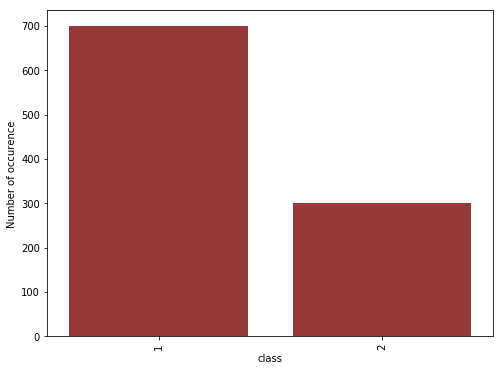

```python
cr_count = credit["class"].value_counts()
plt.figure(figsize=(8,6))
sns.barplot(cr_count.index, cr_count.values, color='brown')
plt.xticks(rotation='vertical')
plt.xlabel('class')
plt.ylabel('Number of occurence')
```

#### Let's now explore other categorical variables

### count of Status_of_existing_checking

```python
credit["Status_of_existing_checking"].value_counts()
```

```
A14    394
A11    274
A12    269
A13     63
Name: Status_of_existing_checking, dtype: int64
```

### Status_of_existing_checking bar chart

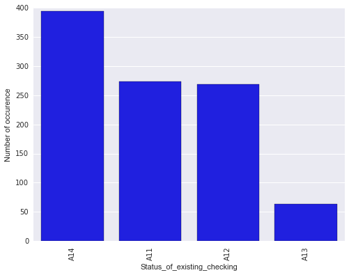

```python
cr_count = credit["Status_of_existing_checking"].value_counts()
plt.figure(figsize=(8,6))
sns.barplot(cr_count.index, cr_count.values, color='blue')
plt.xticks(rotation='vertical')
plt.xlabel('Status_of_existing_checking')
plt.ylabel('Number of occurence')
```

### count of Credit_history

```python
credit["Credit_history"].value_counts()
```

```
A32    530
A34    293
A33     88
A31     49
A30     40
Name: Credit_history, dtype: int64
```

### Credit_history bar chart

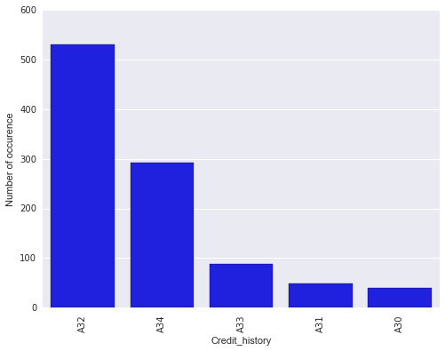

```python
chist_count = credit["Credit_history"].value_counts()
plt.figure(figsize=(8,6))
sns.barplot(chist_count.index, chist_count.values, color='blue')
plt.xticks(rotation='vertical')
plt.xlabel('Credit_history')
plt.ylabel('Number of occurence')
```

### count of Purpose

```python
credit["Purpose"].value_counts()
```

```
A43     280
A40     234
A42     181
A41     103
A49      97
A46      50
A45      22
A410     12
A44      12
A48       9
Name: Purpose, dtype: int64
```

### Purpose bar chart

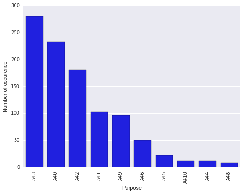

```python
pur_count = credit["Purpose"].value_counts()
plt.figure(figsize=(8,6))
sns.barplot(pur_count.index, pur_count.values, color='blue')
plt.xticks(rotation='vertical')
plt.xlabel('Purpose')
plt.ylabel('Number of occurence')
```

### count of Savings_account

```python
credit["Savings_account"].value_counts()
```

```
A61    603
A65    183
A62    103
A63     63
A64     48
Name: Savings_account, dtype: int64
```

```
Text(0,0.5,'Number of occurence')
```

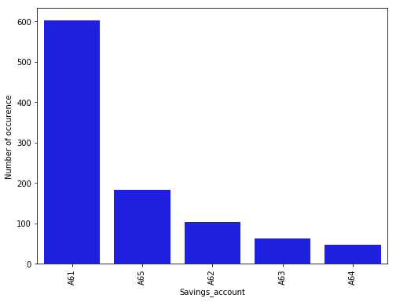

```python
sav_count = credit["Savings_account"].value_counts()
plt.figure(figsize=(8,6))
sns.barplot(sav_count.index, sav_count.values, color='blue')
plt.xticks(rotation='vertical')
plt.xlabel('Savings_account')
plt.ylabel('Number of occurence')
```

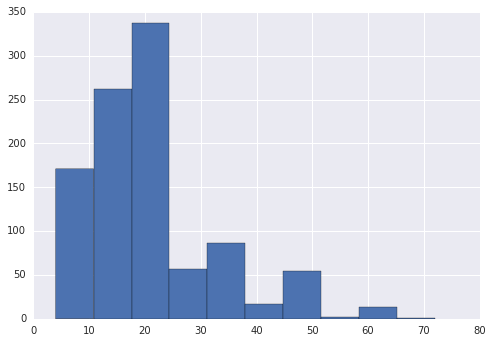

```python
#Histogram for Duration_in_month
credit['Duration_in_month'].hist()
```

[output not shown]

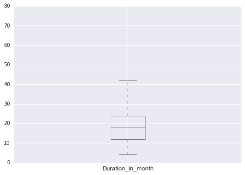

```python
#Boxplot for Duration_in_month
credit.boxplot(column='Duration_in_month')
```

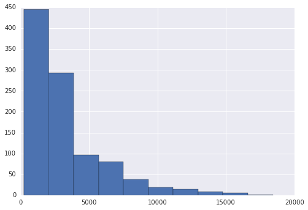

```python
#Histogram for Credit_amount
credit['Credit_amount'].hist()
```

[output not shown]

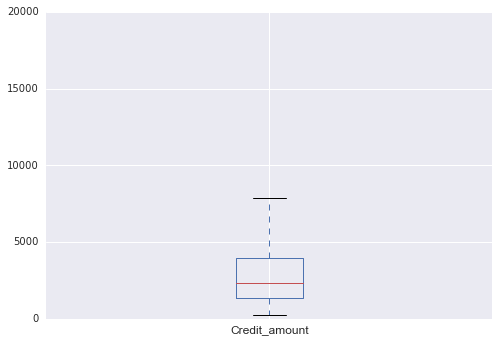

```python
#Boxplot for Credit_amount
credit.boxplot(column='Credit_amount')
```

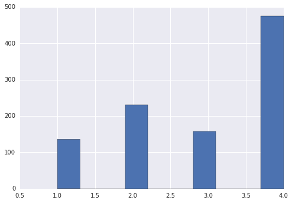

```python
#Histogram for Installment_rate_in_percentage
credit['Installment_rate_in_percentage'].hist()
```

[output not shown]

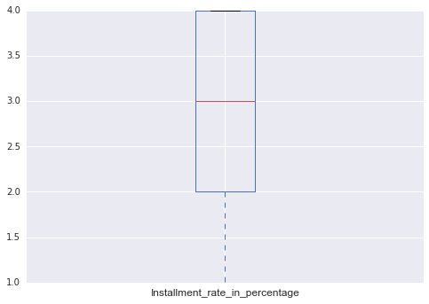

```python
#Boxplot for Installment_rate_in_percentage
credit.boxplot(column='Installment_rate_in_percentage')
```

# Model building

### Pre-processing

Categorical data are in positions 0, 2, 3, 5, 6, 8, 9, 11, 13, 14, 16, 18, and 19

```python
X = credit.iloc[:, 0:-1].values
y = credit.iloc[:, -1].values
```

```python
X[0, 0:20]
```

```
array(['A11', 6, 'A34', 'A43', 1169, 'A65', 'A75', 4, 'A93', 'A101', 4,
       'A121', 67, 'A143', 'A152', 2, 'A173', 1, 'A192', 'A201'],
      dtype=object)
```

```python
y[0:4]
```

```
array([1, 2, 1, 1], dtype=int64)
```

```python
# Encoding categorical data
from sklearn.preprocessing import LabelEncoder, OneHotEncoder
#label encode the categorical variable in position 0
X[:, 0] = LabelEncoder().fit_transform(X[:, 0])
X[0, 0:10]
```

```
array([0, 6, 'A34', 'A43', 1169, 'A65', 'A75', 4, 'A93', 'A101'],
      dtype=object)
```

```python
X[0, 0:20]
```

```
array([0, 6, 'A34', 'A43', 1169, 'A65', 'A75', 4, 'A93', 'A101', 4,
       'A121', 67, 'A143', 'A152', 2, 'A173', 1, 'A192', 'A201'],
      dtype=object)
```

As expected, the first column was label encoded

#### Let's now the same for the rest of the categorical data:

Positions 2, 3, 5, 6, 8, 9, 11, 13, 14, 16, 18, and 19

```python
X[:, 2] = LabelEncoder().fit_transform(X[:, 2])
X[:, 3] = LabelEncoder().fit_transform(X[:, 3])
X[:, 5] = LabelEncoder().fit_transform(X[:, 5])
X[:, 6] = LabelEncoder().fit_transform(X[:, 6])
X[:, 8] = LabelEncoder().fit_transform(X[:, 8])
X[:, 9] = LabelEncoder().fit_transform(X[:, 9])
X[:, 11] = LabelEncoder().fit_transform(X[:, 11])
X[:, 13] = LabelEncoder().fit_transform(X[:, 13])
X[:, 14] = LabelEncoder().fit_transform(X[:, 14])
X[:, 16] = LabelEncoder().fit_transform(X[:, 16])
X[:, 18] = LabelEncoder().fit_transform(X[:, 18])
X[:, 19] = LabelEncoder().fit_transform(X[:, 19])
X[0, 0:10]
```

```
array([0, 6, 4, 4, 1169, 4, 4, 4, 2, 0], dtype=object)
```

```python
X[0, 0:20]
```

```
array([0, 6, 4, 4, 1169, 4, 4, 4, 2, 0, 4, 0, 67, 2, 1, 2, 2, 1, 1, 0],
      dtype=object)
```

Since some categories are up to 4 or more levels, It is important that we one hot encode all categorical variable so that the algorithm can recognize the present of a category as true or false. This will ensure that high weight is not given to the category encoded as 4 while given low weight to the ones encoded as 0. Rather, it will understand it as beign present or absent.

#### categorical positions: 0, 2, 3, 5, 6, 8, 9, 11, 13, 14, 16, 18, and 19

```python
#one hot encode all the categorical variables
onehotencoder = OneHotEncoder(categorical_features = [0, 2, 3, 5, 6, 8, 9, 11, 13, 14, 16, 18, 19])
X = onehotencoder.fit_transform(X).toarray()
```

```python
X[0, 0:]
```

[output not shown]

```python
# Splitting the dataset into the Training set and Test set 75% for training, 25% for test
from sklearn.model_selection import train_test_split
X_train, X_test, y_train, y_test = train_test_split(X, y, test_size = 0.25, random_state = 0)
```

```python
# Feature Scaling
from sklearn.preprocessing import StandardScaler
sc = StandardScaler()
X_train = sc.fit_transform(X_train)
X_test = sc.transform(X_test)
```

```python
X_train[0, 0:]
```

```
array([ 1.14180917,  0.27781426,  0.40669939, -0.12126781,  0.32090437,
       -0.06154432, -0.33825807, -0.89731234,  0.41792845, -0.31180888,
        0.11412108, -0.33479323, -0.08066924,  0.44802639,  0.13153139,
        1.01250495,  0.16292637, -0.41678402, -0.83937206, -0.19324699])
```

```python
X_train.shape
```

```
(750, 20)
```

## let's now train the ANN

```python
# Importing the Keras libraries and packages
import keras
from keras.models import Sequential
from keras.layers import Dense
```

```python
# Initialising the ANN
classifier = Sequential()

# Adding the input layer and the first hidden layer
classifier.add(Dense(units = 10, kernel_initializer = 'uniform', activation = 'relu', input_dim = 20))

# Adding the second hidden layer
classifier.add(Dense(units = 4, kernel_initializer = 'uniform', activation = 'relu'))

# Adding the output layer
classifier.add(Dense(units = 1, kernel_initializer = 'uniform', activation = 'sigmoid'))
```

```python
# Compiling the ANN using stochastic gradient descent optimzer
classifier.compile(optimizer = 'adam', loss = 'binary_crossentropy', metrics = ['accuracy'])
```

```python
# Fitting the ANN to the Training set
classifier.fit(X_train, y_train, batch_size = 10, epochs = 100)
#classifier.fit(X_train, y_train, batch_size = 32, epochs = 200)
```

```
<keras.callbacks.History at 0x25a865b0eb8>
```

## Making predictions and evaluating the model

```python
# Predicting the Test set results
y_pred = classifier.predict(X_test)
y_pred = (y_pred > 0.5)
```

```python
# Making the Confusion Matrix
from sklearn.metrics import confusion_matrix
cm = confusion_matrix(y_test, y_pred)
```

```python
cm
```

```
array([[176,   0],
       [ 74,   0]], dtype=int64)
```

```python
accuracy = (176+0)/(176+0+74+0)
accuracy
```

```
0.704
```

The model predicts all 176 good creadits correctly and fails to predict all bad 74 credits correctly with accuracy of 70%. The model is not a good model especially if the company is interested in detecting the bad credits which is often the case. I suspect either overfitting or underfitting. Also, the class imbalance of 70% to 30% could play a role in the poor performance of the model. In the future, we will need to address the following:

```
1. overfitting and underfitting using cross validation and hyper-parameter tuning.
2. Class imbalance by one of oversampling, undersampling or using hybrid and other heuristic methods.
```